# GGM Simulation. Effect of prior slab variance

```r
library(modelSelection)
library(mvtnorm)
library(tidyverse)
library(lamW)      # Lambert's W_q function
set.seed(20260710) # for reproducibility
save2pdf <- FALSE
```

# Set default prior parameters

We consider a discrete spike-and-slab prior on the precision matrix, with prior slab (edge inclusion) probability $\eta=0.1$. The prior on diagonal elements is $\theta_{ii} \sim \mbox{Exp}(\lambda/2)$, with expectation $\mu= 2/\lambda$, and the prior on off-diagonal elements is $\theta_{ij} \sim N(0, \sigma^2)$. A natural default is $\sigma^2 =1$. If all the columns in the observed dataset are standardized to zero sample mean and unit sample variance, this default is related to Zellner’s unit information prior in regression. We consider three settings:

1. A default $\lambda=1$, and $\sigma^2=1$.
2. A default $\lambda=1$, with $\sigma^2$ specified such that $P(\Theta \succ 0) = 0.95$. This guarantees that the total variation distance between the priors before and after positive-definiteness truncation is small, and hence that the prior is interpretable.
3. Set $\lambda$ such that $P(\Theta_{ii} \succ 0 \mid Z) \geq 1 - \alpha$ for every edge configuration $Z$ and taking $\alpha=0.1$, and $\sigma^2=1$.

```r
edge_prob= 0.1 # probability of non-zero entry
mu = 9.5       # mean of off-diagonal
lambda= 2/mu
pexp(1, rate=lambda/2, lower.tail=FALSE) #equals 0.9
```

```
## [1] 0.9000876
```

We next obtain the value of $\lambda$ for Setting 3.

```r
sd.slab <- 1
alpha <- 0.1
kseq <- c(50, 100)
names(kseq) <- paste('k=', kseq, sep='')
x <- - alpha^2 /(32 * exp(2) * kseq^2)
l <- lambertWm1(x) # q = -1 branch of Lambert's W_q function
mu <- (2 * sd.slab * kseq / alpha) * sqrt(-l)  # liberal upper bound
#mu <- (2 * sd.slab * kseq^(3/2) / alpha) * sqrt(-l) # conservative upper-bound (same results)
lambda2 <- 2/mu
names(lambda2) <- names(kseq)
lambda2
```

```
##         k=50        k=100
## 0.0004370977 0.0002113364
```

Finally, for setting 2, given the prior edge inclusion probability $\eta$ and $\lambda$, function `randompdmatrix_setpars` finds the value of $\sigma^2$ such that $P(\Theta \succ 0)=0.95$. This is done via Monte Carlo, that is sampling from the prior and finding $\sigma$ such that $P(\Theta \succ 0) = 0.95$.

```r
var.slab.setting2 <- double(length(kseq))
names(var.slab.setting2) <- paste('k=', kseq, sep='')
for (i in 1:length(kseq)) {
  var.slab.setting2[i] <- modelSelection:::randompdmatrix_setpars(p=kseq[i], edge_prob=edge_prob, diag_distrib='Exp', diag_mean=2, method='MC')$offdiag_variance
}
```

We store the prior parameter values obtained for each setting and $k = \mbox{dim}(\Theta)$.

```r
priorpars <- expand.grid(setting=c('Setting 1', 'Setting 2', 'Setting 3'), k=kseq)
priorpars$edge_prob <- edge_prob
priorpars$lambda <- priorpars$var.slab <- NA
for (i in 1:nrow(priorpars)) {
  if (priorpars$setting[i] == 'Setting 1') {
    priorpars$lambda[i] <- 1
    priorpars$var.slab[i] <- 1
  } else if (priorpars$setting[i] == 'Setting 2') {
    priorpars$lambda[i] <- 1
    priorpars$var.slab[i] <- var.slab.setting2[paste('k=', priorpars$k[i], sep='')]
  } else if (priorpars$setting[i] == 'Setting 3') {
    priorpars$lambda[i] <- lambda2[paste('k=', priorpars$k[i], sep='')]
    priorpars$var.slab[i] <- 1
  }
}
priorpars
```

```
##     setting   k edge_prob     var.slab       lambda
## 1 Setting 1  50       0.1 1.000000e+00 1.0000000000
## 2 Setting 2  50       0.1 2.175056e-04 1.0000000000
## 3 Setting 3  50       0.1 1.000000e+00 0.0004370977
## 4 Setting 1 100       0.1 1.000000e+00 1.0000000000
## 5 Setting 2 100       0.1 4.517258e-05 1.0000000000
## 6 Setting 3 100       0.1 1.000000e+00 0.0002113364
```

# Function to run simulations

We create a function that simulates data from a multivariate Gaussian, fits a Bayesian Gaussian graphical model model under a discrete spike-and-slab prior, and record the mean squared estimation error, the average estimate of each $\theta_{ij}$ entry, and the average posterior probability $P(\theta_{ij} \neq 0 \mid y)$.

```r
run_simulations <- function(nsims, Theta, Sigma=solve(Theta), priorCoef, priorDiag, priorModel) {
  ans = vector("list", nsims)
  for (i in 1:nsims) {
    set.seed(i)  #for reproducibility

    # Simulate data
    y = rmvnorm(n, sigma= Sigma)
    sy = apply(y, 2, 'sd')

    # Fit models
    fit = modelSelectionGGM(y=y, priorCoef=priorCoef, priorDiag=priorDiag, priorModel=priorModel, verbose=FALSE)

    # Extract BMA parameter estimates and posterior edge inclusion probabilities
    b= data.frame(coef(fit)) |>
      select(row, column, estimate, margpp)

    # Convert to original scale
    scaling = 1 / (sy[b$row] * sy[b$column])
    b = transform(b, estimate= estimate * scaling)

    # Add data-generating truth
    if (i==1) {
      truth = double(nrow(b))
      for (j in 1:nrow(b)) truth[j] = Theta[b$row[j], b$column[j]]
    }
    b$truth = truth

    # Record MSE, average posterior inclusion probability and average point estimate
    ans[[i]] = group_by(b, truth) |>
                 summarize(mse = mean((truth - estimate)^2), pp = mean(margpp), mean_estimate = mean(estimate), count = n()) |>
                 cbind(simid = i)

    cat('.')

  }
  return(ans)
}
```

# Run simulations

```r
nsims <- 20 # number of simulations
n <- 100   # sample size

sims1 <- sims2 <- sims3 <- vector("list", length(kseq))
names(sims1) <- names(sims2) <- names(sims3) <- names(kseq)
for (i in 1:length(kseq)) {
  ksel <- kseq[i]  # number of variables
  cat("Simulations for k =", ksel)

  # Data-generating precision matrix
  Theta= diag(ksel)
  Theta[abs(col(Theta) - row(Theta)) == 1] <- 0.5
  Theta[abs(col(Theta) - row(Theta)) == 2] <- 0.25
  Sigma = solve(Theta)

  # Set prior distribution under each setting
  pars_sel <- filter(priorpars, setting == "Setting 1", k == ksel)
  priorModel <- modelbinomprior(pars_sel$edge_prob)
  priorDiag <- exponentialprior(lambda = pars_sel$lambda)
  priorCoef <- normalidprior(pars_sel$var.slab)
  sims1[[i]] <- run_simulations(nsims, Theta=Theta, Sigma=solve(Theta), priorCoef=priorCoef, priorDiag=priorDiag, priorModel=priorModel)

  pars_sel <- filter(priorpars, setting == "Setting 2", k == ksel)
  priorModel <- modelbinomprior(pars_sel$edge_prob)
  priorDiag <- exponentialprior(lambda = pars_sel$lambda)
  priorCoef <- normalidprior(pars_sel$var.slab)
  sims2[[i]] <- run_simulations(nsims, Theta=Theta, Sigma=solve(Theta), priorCoef=priorCoef, priorDiag=priorDiag, priorModel=priorModel)

  pars_sel <- filter(priorpars, setting == "Setting 3", k == ksel)
  priorModel <- modelbinomprior(pars_sel$edge_prob)
  priorDiag <- exponentialprior(lambda = pars_sel$lambda)
  priorCoef <- normalidprior(pars_sel$var.slab)
  sims3[[i]] <- run_simulations(nsims, Theta=Theta, Sigma=solve(Theta), priorCoef=priorCoef, priorDiag=priorDiag, priorModel=priorModel)

  cat("\n")
}
```

```
## Simulations for k = 50............................................................
## Simulations for k = 100............................................................
```

# Summarize simulations output

We summarize the results across all simulations. For each prior parameter setting and $k= \mbox{dim}(\Theta)$, and each value of the data-generating $\Theta_{ij}$, we report the mean squared estimation error in the Bayesian model averaging estimate $E(\Theta_{ij} \mid y)$, the average marginal posterior edge inclusion probability $P(\Theta_{ij} \neq 0 \mid y)$, and the average BMA estimate.

```r
sim_summary <- vector("list", length(kseq))
names(sim_summary) <- names(kseq)

for (i in 1:length(kseq)) {

  summary1 = do.call(rbind, sims1[[i]]) |>
    data.frame() |>
    group_by(truth) |>
    summarize(across(mse:count, mean)) |>
    transform(k = kseq[i], Setting = "Setting 1")

  summary2 = do.call(rbind, sims2[[i]]) |>
    data.frame() |>
    group_by(truth) |>
    summarize(across(mse:count, mean)) |>
    transform(k = kseq[i], Setting = "Setting 2")

  summary3 = do.call(rbind, sims3[[i]]) |>
    data.frame() |>
    group_by(truth) |>
    summarize(across(mse:count, mean)) |>
    transform(k = kseq[i], Setting = "Setting 3")

  sim_summary[[i]] <- rbind(summary1, summary2, summary3)

}
sim_summary <- do.call(rbind, sim_summary) |>
  transform(root_mse = round(sqrt(mse),3), pp = round(pp,3), mean_estimate = round(mean_estimate, 4)) |>
  select(-mse) |>
  select(Setting, k, root_mse, everything())

rownames(sim_summary) <- NULL
```

```r
sim_summary
```

```
##      Setting   k root_mse truth    pp mean_estimate count
## 1  Setting 1  50    0.015  0.00 0.030       -0.0008  1128
## 2  Setting 1  50    0.155  0.25 0.556        0.1535    48
## 3  Setting 1  50    0.157  0.50 0.949        0.4080    49
## 4  Setting 1  50    0.144  1.00 1.000        0.9998    50
## 5  Setting 2  50    0.000  0.00 0.100        0.0000  1128
## 6  Setting 2  50    0.250  0.25 0.102        0.0002    48
## 7  Setting 2  50    0.499  0.50 0.115        0.0005    49
## 8  Setting 2  50    0.437  1.00 1.000        0.5728    50
## 9  Setting 3  50    0.016  0.00 0.031       -0.0008  1128
## 10 Setting 3  50    0.152  0.25 0.578        0.1648    48
## 11 Setting 3  50    0.148  0.50 0.956        0.4291    49
## 12 Setting 3  50    0.152  1.00 1.000        1.0312    50
## 13 Setting 1 100    0.013  0.00 0.029       -0.0004  4753
## 14 Setting 1 100    0.158  0.25 0.547        0.1529    98
## 15 Setting 1 100    0.161  0.50 0.946        0.4053    99
## 16 Setting 1 100    0.156  1.00 1.000        1.0312   100
## 17 Setting 2 100    0.000  0.00 0.100        0.0000  4753
## 18 Setting 2 100    0.250  0.25 0.100        0.0000    98
## 19 Setting 2 100    0.500  0.50 0.103        0.0001    99
## 20 Setting 2 100    0.439  1.00 1.000        0.5696   100
## 21 Setting 3 100    0.013  0.00 0.029       -0.0004  4753
## 22 Setting 3 100    0.154  0.25 0.569        0.1642    98
## 23 Setting 3 100    0.153  0.50 0.953        0.4264    99
## 24 Setting 3 100    0.172  1.00 1.000        1.0654   100
```

# Plots

We first display the root mean square error, and subsequently the average posterior inclusion probability.

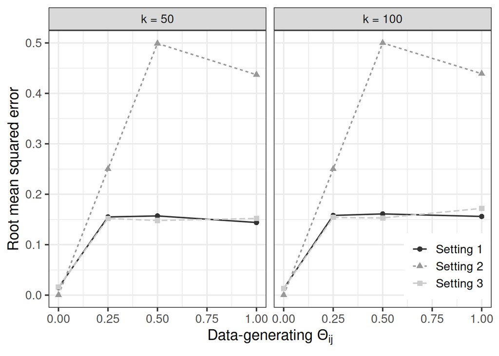

```r
ggplot(sim_summary, aes(x=truth, y=root_mse, col=Setting, lty=Setting, pch=Setting)) +
  geom_line() +
  geom_point() +
  facet_wrap(~ k, labeller = labeller(k = function(x) paste0("k = ", x))) +
  theme_bw(base_size = 15) +
  theme(legend.position = c(0.9, 0.15), legend.title=element_blank()) +
  scale_color_grey() +
  xlab(expression("Data-generating " * Theta[ij])) +
  ylab("Root mean squared error")
```

```r
if (save2pdf) ggsave("sim_priorsettings_rootmse.pdf")
```

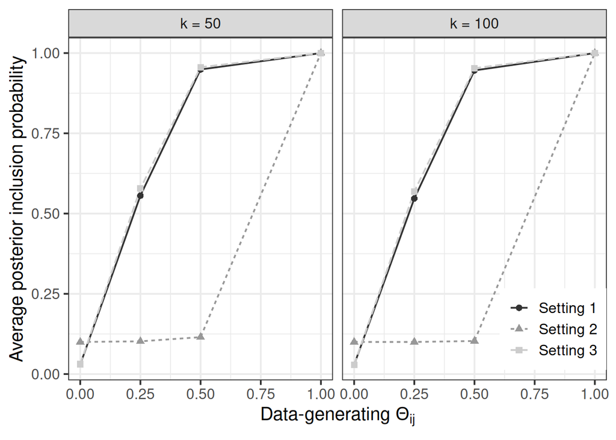

```r
ggplot(sim_summary, aes(x=truth, y=pp, col=Setting, lty=Setting, pch=Setting)) +
  geom_line() +
  geom_point() +
  facet_wrap(~ k, labeller = labeller(k = function(x) paste0("k = ", x))) +
  theme_bw(base_size = 15) +
  theme(legend.position = c(0.9, 0.15), legend.title=element_blank()) +
  scale_color_grey() +
  xlab(expression("Data-generating " * Theta[ij])) +
  ylab("Average posterior inclusion probability")
```

```r
if (save2pdf) ggsave("sim_priorsettings_pp.pdf")
```